# Open data science, spring 2017 - Final assignment

Elina Paakala, 24.2.2017, elina.paakala@helsinki.fi

## Research question:

Dairy bulls and cows are selected for breeding mainly based on their Nordic total merit index. This is a combined index with 14 different traits (for example milk yield, udder health and calving traits). The traits are weighted on their economic importance.

We want to find out if there are different types of bulls used in Finland and what kind of bull groups can be found. There are 14 traits in the index. Can we reduce the traits for further analysis with principal component analysis (PCA)?

After the dimension reduction a cluster analysis can be performed on the principal components. If the dimension reduction isn’t useful the clustering can be done directly with the 14 traits.

On this assignment I only do the PCA.

Data includes two data sets of breeding values of AI (artificial insemination) bulls from two main dairy breeds in Finland (Ayrshire and Holstein) that were used atleast 100 times in Finnish dairy herds during 2015. Bulls that were used less were excluded from the data with Excel on earlier stage.

## Data wrangling:

#### The data wrangling script:

https://github.com/elinapaakala/IODS-final/blob/master/create_bulls.R

Only the 14 variables with traits breeding values were kept in the data for PCA.

## Read in and explore the data

```r
AY_PCA <- read.csv("H:/Jatko-opinnot/Open data science/IODS-final/AY_PCA.csv", sep=",", header=TRUE)
HOL_PCA <- read.csv("H:/Jatko-opinnot/Open data science/IODS-final/HOL_PCA.csv", sep=",", header=TRUE)
```

```r
str(AY_PCA)
```

```
## 'data.frame':    176 obs. of  15 variables:
##  $ X             : int  1 2 3 4 5 6 7 8 9 10 ...
##  $ Yield         : int  97 98 83 111 92 117 115 113 119 122 ...
##  $ Growth        : int  81 105 82 97 89 103 108 109 95 99 ...
##  $ Fertility     : int  80 109 88 100 105 109 99 121 96 108 ...
##  $ Birth         : int  97 98 91 94 93 105 100 103 97 101 ...
##  $ Calving       : int  105 114 99 105 99 97 98 103 97 100 ...
##  $ Udder.health  : int  105 108 94 99 106 108 103 100 107 104 ...
##  $ Other.diseases: int  98 109 79 102 101 104 109 106 100 105 ...
##  $ Frame         : int  109 101 110 107 105 102 94 95 114 115 ...
##  $ Feet...Legs   : int  104 85 110 104 113 108 103 115 97 96 ...
##  $ Udder         : int  121 113 116 115 111 110 105 103 116 114 ...
##  $ Milkability   : int  93 82 94 125 96 111 108 107 102 114 ...
##  $ Temperament   : int  93 84 103 114 87 104 102 98 108 107 ...
##  $ Longevity     : int  96 103 72 109 109 118 116 119 108 118 ...
##  $ Claw.health   : int  111 94 104 106 116 99 101 116 97 96 ...
```

```r
str(HOL_PCA)
```

```
## 'data.frame':    232 obs. of  15 variables:
##  $ X             : int  1 2 3 4 5 6 7 8 9 10 ...
##  $ Yield         : int  105 120 107 113 115 112 112 125 110 117 ...
##  $ Growth        : int  80 82 100 93 102 98 91 108 104 110 ...
##  $ Fertility     : int  94 102 98 82 106 111 99 103 111 109 ...
##  $ Birth         : int  92 117 100 97 96 107 108 100 112 115 ...
##  $ Calving       : int  95 104 113 89 95 99 114 107 113 103 ...
##  $ Udder.health  : int  97 107 101 94 100 117 104 105 115 101 ...
##  $ Other.diseases: int  89 103 100 98 109 104 112 105 108 109 ...
##  $ Frame         : int  114 123 114 129 101 96 113 107 103 93 ...
##  $ Feet...Legs   : int  103 115 102 104 126 109 105 108 96 106 ...
##  $ Udder         : int  112 108 126 116 103 107 117 109 113 110 ...
##  $ Milkability   : int  113 90 102 111 104 97 109 102 98 120 ...
##  $ Temperament   : int  98 102 97 105 97 107 111 104 99 107 ...
##  $ Longevity     : int  93 113 109 100 117 124 106 113 120 116 ...
##  $ Claw.health   : int  85 112 100 98 102 104 109 102 99 100 ...
```

There are 176 Ayrshire bulls and 232 Holstein bulls in the data sets.

Both datasets include the same variables:

| Variable | Description |
| --- | --- |
| BovineIdBull | Bulls ID in the Finnish cattle database |
| Freq | Number of times the bull was used inseminations in 2015 |
| BirthCountry | Birth country of the bull, CAN = Canada, DNK = Denmark, FIN = Finland, NOR = Norway, SWE = Sweden and USA = United States |
| BirthYear | Birth year of the bull |
| NameLong | Bulls name |
| Yield | Breeding value(BV) for milk yield |
| Growth | BV for growth |
| Fertility | BV for fertility |
| Birth | BV for birth index |
| Calving | BV for calving index |
| Udder.health | BV for udder health |
| Other.diseases | BV for other diseases (than udder and claw diseases) |
| Frame | BV for frame conformation |
| Feet..Legs | BV for feet and leg conformation |
| Udder | BV for udder conformation |
| Milkability | BV for milkability (milking speed) |
| Temperament | BV for temperament |
| Longevity | BV for longevity |
| Claw.health | BV for claw health |

### Summaries of the variables

```r
summary(AY_PCA)
```

```
##        X              Yield           Growth         Fertility
##  Min.   :  1.00   Min.   : 67.0   Min.   : 64.00   Min.   : 80.0
##  1st Qu.: 44.75   1st Qu.:108.8   1st Qu.: 94.00   1st Qu.: 99.0
##  Median : 88.50   Median :112.0   Median : 99.50   Median :103.0
##  Mean   : 88.50   Mean   :109.6   Mean   : 97.93   Mean   :102.7
##  3rd Qu.:132.25   3rd Qu.:115.0   3rd Qu.:104.00   3rd Qu.:107.0
##  Max.   :176.00   Max.   :128.0   Max.   :117.00   Max.   :126.0
##      Birth          Calving       Udder.health   Other.diseases
##  Min.   : 72.0   Min.   : 77.0   Min.   : 91.0   Min.   : 69.0
##  1st Qu.: 98.0   1st Qu.:100.0   1st Qu.:102.0   1st Qu.:100.0
##  Median :103.0   Median :104.0   Median :105.0   Median :104.0
##  Mean   :102.3   Mean   :103.7   Mean   :105.6   Mean   :103.3
##  3rd Qu.:108.0   3rd Qu.:107.0   3rd Qu.:110.0   3rd Qu.:108.0
##  Max.   :125.0   Max.   :118.0   Max.   :121.0   Max.   :119.0
##      Frame        Feet...Legs        Udder        Milkability
##  Min.   : 76.0   Min.   : 81.0   Min.   : 88.0   Min.   : 74.0
##  1st Qu.: 98.0   1st Qu.: 99.0   1st Qu.:104.0   1st Qu.: 96.0
##  Median :102.0   Median :105.0   Median :108.5   Median :103.5
##  Mean   :102.3   Mean   :104.9   Mean   :108.8   Mean   :103.5
##  3rd Qu.:106.0   3rd Qu.:111.0   3rd Qu.:113.0   3rd Qu.:110.0
##  Max.   :128.0   Max.   :122.0   Max.   :129.0   Max.   :128.0
##   Temperament      Longevity      Claw.health
##  Min.   : 84.0   Min.   : 72.0   Min.   : 76.0
##  1st Qu.: 98.0   1st Qu.:106.8   1st Qu.: 99.0
##  Median :102.0   Median :111.0   Median :104.0
##  Mean   :102.2   Mean   :109.4   Mean   :103.6
##  3rd Qu.:107.2   3rd Qu.:116.0   3rd Qu.:107.0
##  Max.   :121.0   Max.   :130.0   Max.   :127.0
```

```r
summary(HOL_PCA)
```

```
##        X              Yield           Growth         Fertility
##  Min.   :  1.00   Min.   : 89.0   Min.   : 66.00   Min.   : 75.0
##  1st Qu.: 58.75   1st Qu.:106.0   1st Qu.: 91.00   1st Qu.: 99.0
##  Median :116.50   Median :113.0   Median : 97.00   Median :107.0
##  Mean   :116.50   Mean   :112.3   Mean   : 97.28   Mean   :106.1
##  3rd Qu.:174.25   3rd Qu.:117.0   3rd Qu.:105.00   3rd Qu.:113.0
##  Max.   :232.00   Max.   :137.0   Max.   :125.00   Max.   :135.0
##      Birth          Calving       Udder.health   Other.diseases
##  Min.   : 71.0   Min.   : 77.0   Min.   : 80.0   Min.   : 73.0
##  1st Qu.: 98.0   1st Qu.:103.0   1st Qu.:102.0   1st Qu.:100.0
##  Median :104.0   Median :107.0   Median :107.0   Median :105.0
##  Mean   :102.9   Mean   :106.3   Mean   :106.6   Mean   :104.3
##  3rd Qu.:108.0   3rd Qu.:111.0   3rd Qu.:112.0   3rd Qu.:109.0
##  Max.   :121.0   Max.   :122.0   Max.   :124.0   Max.   :120.0
##      Frame        Feet...Legs        Udder        Milkability
##  Min.   : 84.0   Min.   : 89.0   Min.   : 88.0   Min.   : 68.0
##  1st Qu.:101.0   1st Qu.:101.8   1st Qu.:108.0   1st Qu.: 95.0
##  Median :109.0   Median :106.0   Median :114.0   Median :101.0
##  Mean   :109.5   Mean   :106.0   Mean   :114.3   Mean   :101.8
##  3rd Qu.:117.0   3rd Qu.:110.0   3rd Qu.:119.0   3rd Qu.:109.0
##  Max.   :136.0   Max.   :126.0   Max.   :142.0   Max.   :126.0
##   Temperament      Longevity      Claw.health
##  Min.   : 76.0   Min.   : 80.0   Min.   : 77.0
##  1st Qu.: 99.0   1st Qu.:110.0   1st Qu.:101.0
##  Median :104.0   Median :116.0   Median :105.0
##  Mean   :103.9   Mean   :114.7   Mean   :105.1
##  3rd Qu.:108.0   3rd Qu.:121.0   3rd Qu.:111.0
##  Max.   :122.0   Max.   :141.0   Max.   :125.0
```

The breeding values have mean of 100 and standard deviation of 10 in the population level. In these datasets the means are in most cases over 100 because the AI bulls (usually) are the individuals that have the best breeding values of the whole population. But there are also bulls with very low breeding values because farmers sometimes want to use bulls with high BVs on some certain trait and do not then care about other traits.

For some reason R puts an extra varaibal X to both data sets. This has to be removed before the PCA.

```r
AY_PCA = subset(AY_PCA, select = -c(1))
HOL_PCA = subset(HOL_PCA, select = -c(1))
```

### Histograms of variables

#### Ayrshire bulls

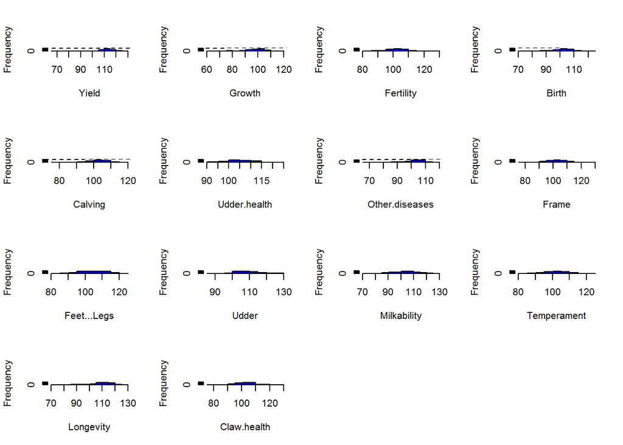

```r
library(plyr)
library(psych)
multi.hist(AY_PCA, freq=TRUE, bcol="blue", main="")
```

#### Holstein bulls

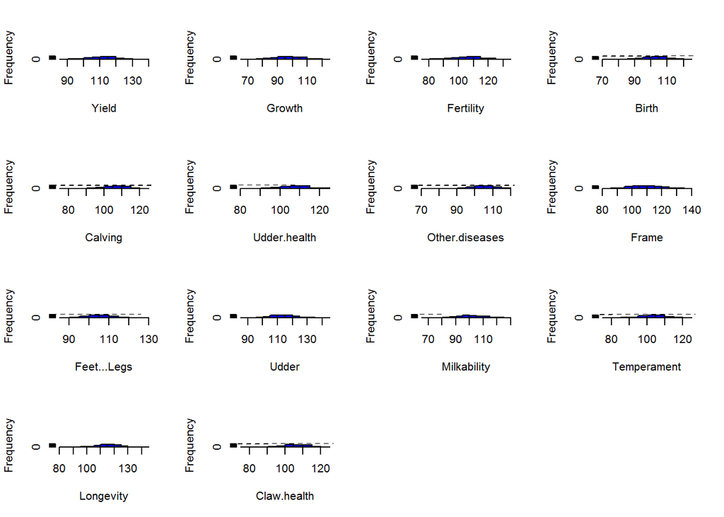

```r
multi.hist(HOL_PCA, freq=TRUE, bcol="blue", main="")
```

(The histograms did not look this flat in RStudio.) All variables in both breeds are nicely evenly distributed.

### Correlations between different breeding values in Ayrshire bulls

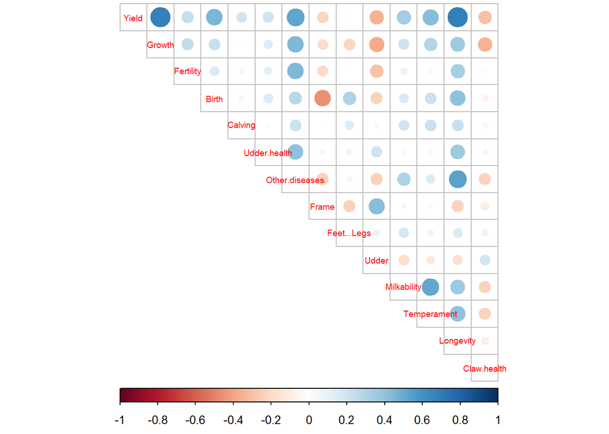

```r
library(corrplot)
library(tidyverse)
cor_matrix_AY<-cor(AY_PCA) %>% round(digits=2)

corrplot(cor_matrix_AY, method="circle", type="upper", cl.pos="b", tl.pos="d", tl.cex=0.6)
```

Highest positive correlations are between Yield and Growth as well as Yield and Longevity and strongest negative correlation between Birth and Frame.

### Correlations between different breeding values in Holstein bulls

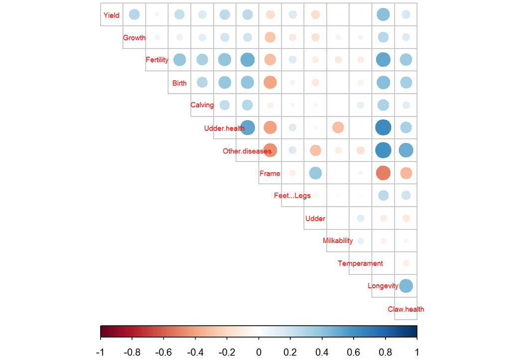

```r
cor_matrix_HOL<-cor(HOL_PCA) %>% round(digits=2)

corrplot(cor_matrix_HOL, method="circle", type="upper", cl.pos="b", tl.pos="d", tl.cex=0.6)
```

Highest positive correlations can be found between Udder Health and Longevity as well as between Other Diseases and Longevity and highest negative correalation can be found between Frame and Longevity.

## PCA

Principal component analysis (PCA) is a statistical technique to reduce the variables in the data. It combines the correlated variables into uncorrelated variables called principal components (PC). The number of PC is equal or less than the original number of variables. With less variables (components) interpretation of data is easier.

### PCA on unstandardized data for Ayrshire bulls

```r
pca_AY = prcomp(AY_PCA)
```

#### Summary

```r
s_pca_AY <- summary(pca_AY)
s_pca_AY
```

```
## Importance of components:
##                            PC1     PC2     PC3     PC4    PC5     PC6
## Standard deviation     17.5912 10.4988 10.0286 8.33594 7.5094 6.75274
## Proportion of Variance  0.3485  0.1241  0.1133 0.07825 0.0635 0.05135
## Cumulative Proportion   0.3485  0.4726  0.5858 0.66408 0.7276 0.77893
##                            PC7     PC8     PC9    PC10    PC11   PC12
## Standard deviation     6.00047 5.87172 5.41782 5.20950 4.93849 4.0202
## Proportion of Variance 0.04054 0.03882 0.03305 0.03056 0.02746 0.0182
## Cumulative Proportion  0.81947 0.85830 0.89135 0.92191 0.94937 0.9676
##                           PC13    PC14
## Standard deviation     3.92522 3.65920
## Proportion of Variance 0.01735 0.01508
## Cumulative Proportion  0.98492 1.00000
```

#### The percentages of variance

```r
pca_AY_pr <- round(100*s_pca_AY$importance[2, ], digits = 1)
pca_AY_pr
```

```
##  PC1  PC2  PC3  PC4  PC5  PC6  PC7  PC8  PC9 PC10 PC11 PC12 PC13 PC14
## 34.8 12.4 11.3  7.8  6.3  5.1  4.1  3.9  3.3  3.1  2.7  1.8  1.7  1.5
```

#### The biplot

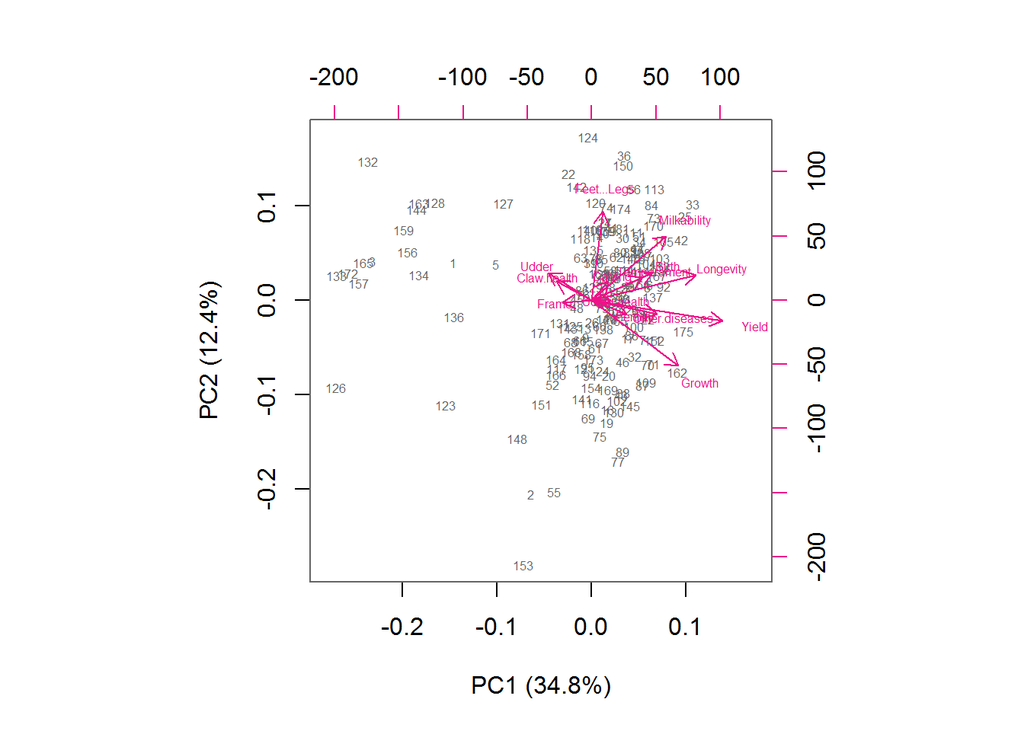

```r
pc_AY_lab <- paste0(names(pca_AY_pr), " (", pca_AY_pr, "%)")
biplot(pca_AY, cex = c(0.5, 0.5), col = c("grey40", "deeppink2"), xlab = pc_AY_lab[1], ylab = pc_AY_lab[2])
```

The first principal component captures 34.8 % of the variation, the second 12.4 % and the third 11.3 %. The first component is not very large. Also the arrows in the biplot don’t give very clear picture of the components. First component could be called Production - Conformation. The longest arrows to the right (Yield, Longevity, Growt and Milkability) describe production traits and arrows to the left (Udder and Frame) describe the conformation of cow. The arrows to right and left are moderately correlated with each other as was seen also in the correlation plot. The second component has only Feet and legs describing it. First four components explain two third of the variance. This indicas that reducing the variables isn’t usuful with this data.

### PCA on standardized data for Ayrshire bulls

```r
AY_PCA_std <- scale(AY_PCA)
pca_AY_std = prcomp(AY_PCA_std)
```

#### Summary

```r
s_pca_AY_std <- summary(pca_AY_std)
s_pca_AY_std
```

```
## Importance of components:
##                           PC1    PC2    PC3    PC4     PC5     PC6     PC7
## Standard deviation     2.0016 1.2906 1.2547 1.1854 0.99957 0.89937 0.88995
## Proportion of Variance 0.2862 0.1190 0.1124 0.1004 0.07137 0.05778 0.05657
## Cumulative Proportion  0.2862 0.4052 0.5176 0.6180 0.68934 0.74712 0.80369
##                            PC8     PC9    PC10    PC11    PC12    PC13
## Standard deviation     0.76648 0.70583 0.67613 0.64296 0.58916 0.52581
## Proportion of Variance 0.04196 0.03559 0.03265 0.02953 0.02479 0.01975
## Cumulative Proportion  0.84565 0.88124 0.91389 0.94342 0.96822 0.98796
##                           PC14
## Standard deviation     0.41048
## Proportion of Variance 0.01204
## Cumulative Proportion  1.00000
```

#### The percentages of variance

```r
pca_AY_std_pr <- round(100*s_pca_AY_std$importance[2, ], digits = 1)
pca_AY_std_pr
```

```
##  PC1  PC2  PC3  PC4  PC5  PC6  PC7  PC8  PC9 PC10 PC11 PC12 PC13 PC14
## 28.6 11.9 11.2 10.0  7.1  5.8  5.7  4.2  3.6  3.3  3.0  2.5  2.0  1.2
```

#### The biplot

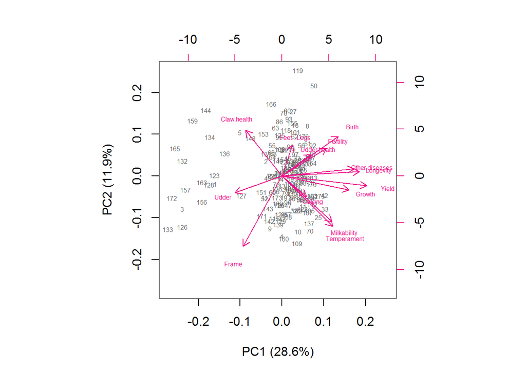

```r
pc_AY_std_lab <- paste0(names(pca_AY_std_pr), " (", pca_AY_std_pr, "%)")
biplot(pca_AY_std, cex = c(0.5, 0.5), col = c("grey40", "deeppink2"), xlab = pc_AY_std_lab[1], ylab = pc_AY_std_lab[2])
```

Standardizing the data reduces the percentage of variation captured by the first component. It is now only 28.6 %. This indicates that maybe standardization isn’t needed. This is supported also by the fact that the variables were originally on the same scale and standardized (mean = 100, sd = 10). The arrows are now longer but still pointing more or less to the same directions as with unstandardized data.

### PCA on unstandardized data for Holstein bulls

```r
pca_HOL = prcomp(HOL_PCA)
```

#### Summary

```r
s_pca_HOL <- summary(pca_HOL)
s_pca_HOL
```

```
## Importance of components:
##                            PC1     PC2     PC3     PC4     PC5    PC6
## Standard deviation     17.7810 11.1672 9.71078 9.31596 8.34008 7.9277
## Proportion of Variance  0.3084  0.1216 0.09198 0.08465 0.06785 0.0613
## Cumulative Proportion   0.3084  0.4300 0.52200 0.60665 0.67450 0.7358
##                            PC7     PC8     PC9    PC10    PC11    PC12
## Standard deviation     7.29987 6.80923 6.40474 5.76751 5.61220 5.22489
## Proportion of Variance 0.05198 0.04522 0.04001 0.03245 0.03072 0.02663
## Cumulative Proportion  0.78778 0.83300 0.87301 0.90546 0.93618 0.96281
##                          PC13  PC14
## Standard deviation     4.5505 4.174
## Proportion of Variance 0.0202 0.017
## Cumulative Proportion  0.9830 1.000
```

#### The percentages of variance

```r
pca_HOL_pr <- round(100*s_pca_HOL$importance[2, ], digits = 1)
pca_HOL_pr
```

```
##  PC1  PC2  PC3  PC4  PC5  PC6  PC7  PC8  PC9 PC10 PC11 PC12 PC13 PC14
## 30.8 12.2  9.2  8.5  6.8  6.1  5.2  4.5  4.0  3.2  3.1  2.7  2.0  1.7
```

#### The biplot

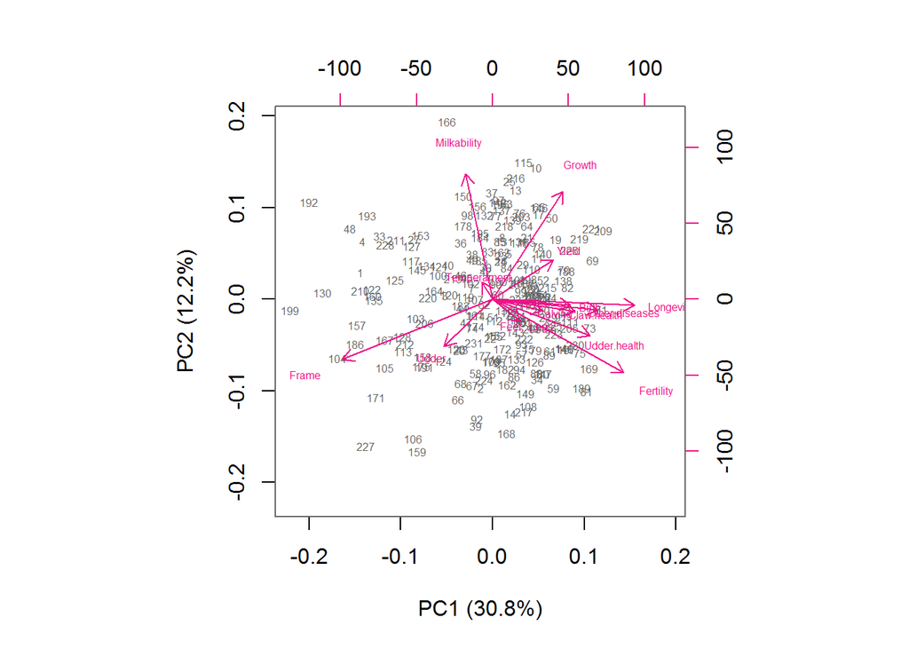

```r
pc_HOL_lab <- paste0(names(pca_HOL_pr), " (", pca_HOL_pr, "%)")
biplot(pca_HOL, cex = c(0.5, 0.5), col = c("grey40", "deeppink2"), xlab = pc_HOL_lab[1], ylab = pc_HOL_lab[2])
```

30.8 % of variance is captured by the first principal component and 12.2 % by the second. Longevity is positively highly correlated health and fertility traits which can be seen from the biplot as well as from the correlation plot. Arrows pointing to left are Udder and Frame conformation. The first component could there fore be called Vitality - Conformation. This is a bit surprising as Udder conformation is in general thought to be associated with longer productive life (Longevity) and better health but on the other hand Frame is not.

### PCA on standardized data for Holstein bulls

```r
HOL_PCA_std <- scale(HOL_PCA)
pca_HOL_std = prcomp(HOL_PCA_std)
```

#### Summary

```r
s_pca_HOL_std <- summary(pca_HOL_std)
s_pca_HOL_std
```

```
## Importance of components:
##                           PC1    PC2     PC3     PC4     PC5     PC6
## Standard deviation     2.0310 1.1719 1.13263 1.04843 1.01837 0.94314
## Proportion of Variance 0.2946 0.0981 0.09163 0.07852 0.07408 0.06354
## Cumulative Proportion  0.2946 0.3927 0.48436 0.56288 0.63695 0.70049
##                            PC7     PC8     PC9    PC10    PC11   PC12
## Standard deviation     0.91747 0.85342 0.80006 0.73745 0.70054 0.6328
## Proportion of Variance 0.06013 0.05202 0.04572 0.03885 0.03505 0.0286
## Cumulative Proportion  0.76062 0.81264 0.85836 0.89721 0.93226 0.9609
##                           PC13    PC14
## Standard deviation     0.54032 0.50601
## Proportion of Variance 0.02085 0.01829
## Cumulative Proportion  0.98171 1.00000
```

#### The percentages of variance

```r
pca_HOL_std_pr <- round(100*s_pca_HOL_std$importance[2, ], digits = 1)
pca_HOL_std_pr
```

```
##  PC1  PC2  PC3  PC4  PC5  PC6  PC7  PC8  PC9 PC10 PC11 PC12 PC13 PC14
## 29.5  9.8  9.2  7.9  7.4  6.4  6.0  5.2  4.6  3.9  3.5  2.9  2.1  1.8
```

#### The biplot

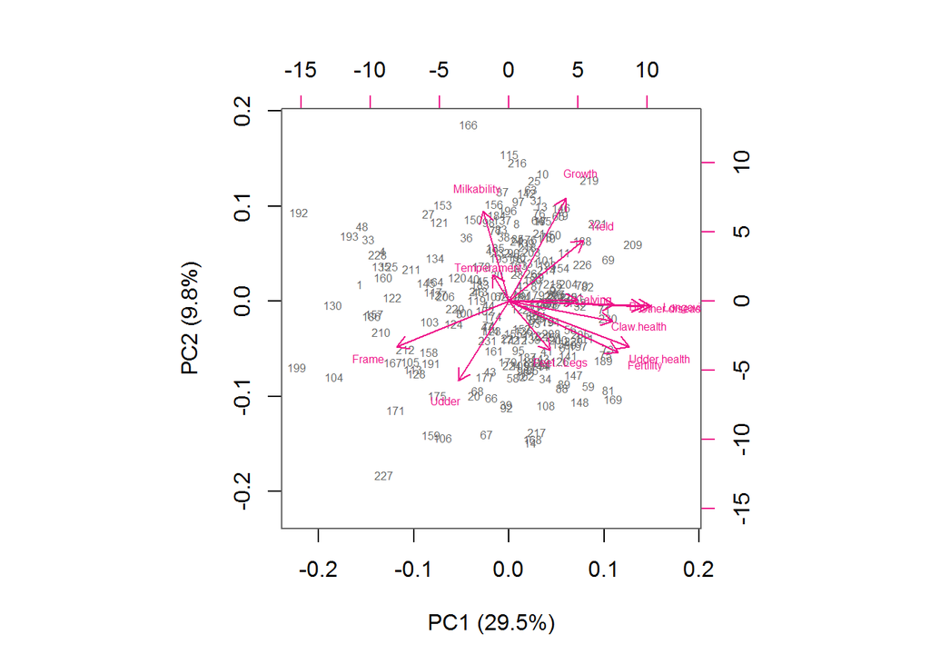

```r
pc_HOL_std_lab <- paste0(names(pca_HOL_std_pr), " (", pca_HOL_std_pr, "%)")
biplot(pca_HOL_std, cex = c(0.5, 0.5), col = c("grey40", "deeppink2"), xlab = pc_HOL_std_lab[1], ylab = pc_HOL_std_lab[2])
```

With Holstein the difference between unstandardized and standardized data in percanteges of variance and the biplot are even smaller than with Ayrshire data.

## Conclusions an discussion

Standardizing the data did not make much difference in either breed. This is because the original data was already standardized and in same scale. Percentage of variance for the first principal component was quite low in each case. Also, it was hard to find clear descriptions for the first two components in each case. Therefore the conlusion is that reducing the varaibles isn’t usefull for further analysis. However, the PCA shows (which came clear in further analyses of my actual study (not included in this report)) that conformation traits (Frame and Udder) versus all other traits seperate the bulls the most.